# PART-A

DOMAIN: Automobile

•CONTEXT: The data concerns city-cycle fuel consumption in miles per gallon to be predicted in terms of 3 multivalued discrete and 5 continuous attributes

PROJECT OBJECTIVE: To understand K-means Clustering by applying on the Car Dataset to segment the cars into various categories.

### 1. Data Understanding & Exploration:

```python
import pandas as pd
import json
import matplotlib.pyplot as plt
import seaborn as sns
import numpy as np
from sklearn import preprocessing, svm
from scipy.stats import zscore, norm
from sklearn.impute import SimpleImputer
from sklearn.preprocessing import LabelEncoder, StandardScaler
from sklearn.metrics import accuracy_score,confusion_matrix,recall_score,classification_report
from sklearn.model_selection import cross_val_score
from sklearn.model_selection import train_test_split, GridSearchCV, StratifiedKFold
from sklearn.decomposition import PCA
```

```python
#A. Read ‘Car name.csv’ as a DataFrame and assign it to a variable
print("----Car name----\n")
carnamedf=pd.read_csv('Carname.csv')
print("Shape",carnamedf.shape)
carnamedf.head()
```

```
----Car name----

Shape (398, 1)
```

|  | car_name |
| --- | --- |
| 0 | chevrolet chevelle malibu |
| 1 | buick skylark 320 |
| 2 | plymouth satellite |
| 3 | amc rebel sst |
| 4 | ford torino |

```python
#B. Read ‘Car-Attributes.json as a DataFrame and assign it to a variable.
print("----Car Attributes----\n")
with open('Car-Attributes.json', "r") as f:
    data = json.loads(f.read())
carattridf=pd.DataFrame.from_dict(data, orient='columns')
print("Shape",carattridf.shape)
carattridf.head()
```

```
----Car Attributes----

Shape (398, 8)
```

|  | acc | cyl | disp | hp | mpg | origin | wt | yr |
| --- | --- | --- | --- | --- | --- | --- | --- | --- |
| 0 | 12.0 | 8 | 307.0 | 130 | 18.0 | 1 | 3504 | 70 |
| 1 | 11.5 | 8 | 350.0 | 165 | 15.0 | 1 | 3693 | 70 |
| 2 | 11.0 | 8 | 318.0 | 150 | 18.0 | 1 | 3436 | 70 |
| 3 | 12.0 | 8 | 304.0 | 150 | 16.0 | 1 | 3433 | 70 |
| 4 | 10.5 | 8 | 302.0 | 140 | 17.0 | 1 | 3449 | 70 |

```python
#C. Merge both the DataFrames together to form a single DataFrame
print("----Combined Car DF----\n")
Cardf=pd.concat([carnamedf,carattridf],axis=1)
print("Shape",Cardf.shape)
Cardf.head()
```

```
----Combined Car DF----

Shape (398, 9)
```

|  | car_name | acc | cyl | disp | hp | mpg | origin | wt | yr |
| --- | --- | --- | --- | --- | --- | --- | --- | --- | --- |
| 0 | chevrolet chevelle malibu | 12.0 | 8 | 307.0 | 130 | 18.0 | 1 | 3504 | 70 |
| 1 | buick skylark 320 | 11.5 | 8 | 350.0 | 165 | 15.0 | 1 | 3693 | 70 |
| 2 | plymouth satellite | 11.0 | 8 | 318.0 | 150 | 18.0 | 1 | 3436 | 70 |
| 3 | amc rebel sst | 12.0 | 8 | 304.0 | 150 | 16.0 | 1 | 3433 | 70 |
| 4 | ford torino | 10.5 | 8 | 302.0 | 140 | 17.0 | 1 | 3449 | 70 |

```python
#D. Print 5 point summary of the numerical features and share insights.
Cardf.describe(include='all')
```

|  | car_name | acc | cyl | disp | hp | mpg | origin | wt | yr |
| --- | --- | --- | --- | --- | --- | --- | --- | --- | --- |
| count | 398 | 398.000000 | 398.000000 | 398.000000 | 398.0 | 398.000000 | 398.000000 | 398.000000 | 398.000000 |
| unique | 305 | NaN | NaN | NaN | 94.0 | NaN | NaN | NaN | NaN |
| top | ford pinto | NaN | NaN | NaN | 150.0 | NaN | NaN | NaN | NaN |
| freq | 6 | NaN | NaN | NaN | 22.0 | NaN | NaN | NaN | NaN |
| mean | NaN | 15.568090 | 5.454774 | 193.425879 | NaN | 23.514573 | 1.572864 | 2970.424623 | 76.010050 |
| std | NaN | 2.757689 | 1.701004 | 104.269838 | NaN | 7.815984 | 0.802055 | 846.841774 | 3.697627 |
| min | NaN | 8.000000 | 3.000000 | 68.000000 | NaN | 9.000000 | 1.000000 | 1613.000000 | 70.000000 |
| 25% | NaN | 13.825000 | 4.000000 | 104.250000 | NaN | 17.500000 | 1.000000 | 2223.750000 | 73.000000 |
| 50% | NaN | 15.500000 | 4.000000 | 148.500000 | NaN | 23.000000 | 1.000000 | 2803.500000 | 76.000000 |
| 75% | NaN | 17.175000 | 8.000000 | 262.000000 | NaN | 29.000000 | 2.000000 | 3608.000000 | 79.000000 |
| max | NaN | 24.800000 | 8.000000 | 455.000000 | NaN | 46.600000 | 3.000000 | 5140.000000 | 82.000000 |

```python
#discrete value analysis
print("car cylinder frequency")
print(Cardf['cyl'].value_counts())
print("\n\ncar origin frequency")
print(Cardf['origin'].value_counts())
print("\n\ncar year frequency")
print(Cardf['yr'].value_counts())
```

```
car cylinder frequency
4    204
8    103
6     84
3      4
5      3
Name: cyl, dtype: int64


car origin frequency
1    249
3     79
2     70
Name: origin, dtype: int64


car year frequency
73    40
78    36
76    34
82    31
75    30
81    29
80    29
79    29
70    29
77    28
72    28
71    28
74    27
Name: yr, dtype: int64
```

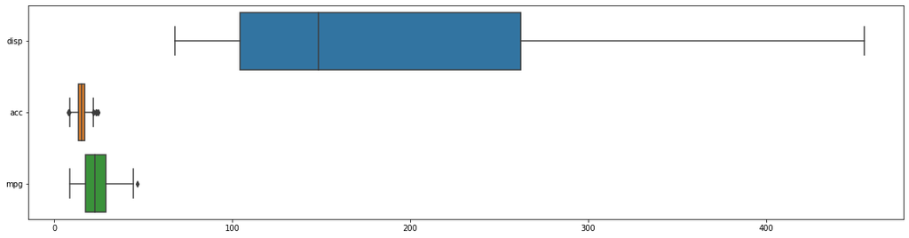

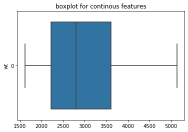

```python
#continuous feature analysis
contclms=['disp','acc','hp','mpg']
fig = plt.figure(figsize = (20, 5))
ax = sns.boxplot(data = Cardf[contclms], orient = 'h')
plt.show()
ax = sns.boxplot(data = Cardf['wt'], orient = 'h')
plt.ylabel('wt')
plt.title('boxplot for continous features')
plt.show()
```

**1. Accelearation:**

-Mean and median of the data is almost same . Hence normally distributed feature.

-It ranges from 8 to 24 .

-75% of data falls under 17 . outliers are observed.

**2. Cylinder**

-A discrete value [3,4,5,6,8] are the possible values.

-Most of the cars have 4 cylinders and and fewer cars have 3 and 5 cylinders

**3. Displacement :**

-mean is greater than median ; observed right skew in the data.

-75% of data falls under 262 .

**4. Hp:**

-seems to have unexpected value .

After imputing unexpected value: HP seems to be right skewed and has some outliers abover upperfence

**5. MPG:**

-mean and median are almost same, normally distributed .

-minimum MPG is 9 and maximum MPG is 46 and

-75% of data falls under 29, outliers are observed.

**6. ORIGIN:**

-is a discrete value [1,2,3] are possible values .

-Most of the cars fall under origin -1

**7. Wt :**

-mean is greater than median ; Slightly right skewed .

-Minimum weight is 1613 and maximum weight is 5140

-75% of data is within 3608

**8. Yr:**

-year starts from 70s to 82s Maximum car originated in the year 73

### 2. Data Preparation & Analysis:

```python
#A. Check and print feature-wise percentage of missing values present in the data and impute with the best suitable approach
missingvalue=False
for feature in Cardf.columns:
     #check for NaN values
    if(Cardf[feature].isnull().sum()!=0 or Cardf[feature].isna().sum()!=0 ):
        print("Data missing in column", feature)
        #impute
        impute = SimpleImputer(missing_values = np.nan, strategy = 'mean', verbose = 1)
        Cardf[feature] =impute.fit_transform(Cardf[feature] )
        missingvalue= True
if(not missingvalue):
    print("No Missing Values")


round((Cardf.isnull().sum()/len(Cardf))*100,2)
```

```
No Missing Values
```

```
car_name    0.0
acc         0.0
cyl         0.0
disp        0.0
hp          0.0
mpg         0.0
origin      0.0
wt          0.0
yr          0.0
dtype: float64
```

```python
#B. Check for duplicate values in the data and impute with the best suitable approach.
if (Cardf.duplicated().sum()>0):
    Cardf.drop_duplicates(keep='first', inplace=True)
else :
    print("No Duplicates ")
```

```
No Duplicates
```

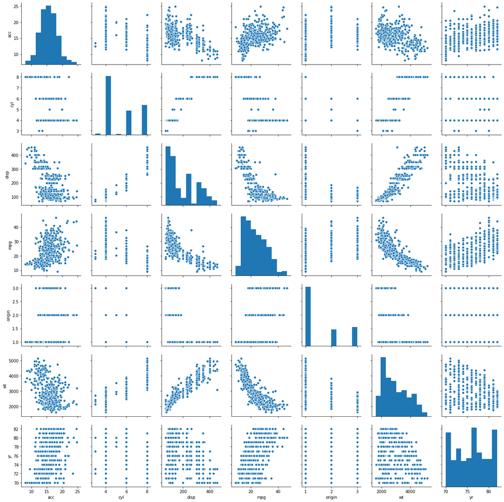

```python
#C. Plot a pairplot for all features
sns.pairplot(Cardf)
plt.show()
```

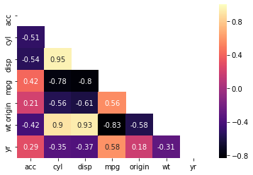

```python
mask = np.triu(np.ones_like(Cardf.corr()))
sns.heatmap(Cardf.corr(),annot=True,mask=mask,cmap="magma")
```

**Insights**

cylinder have positive correlation with displacement,hp and weight and negative correlation with mpg

Horse power is positively correlated with cylinder,weight and displacement

MPG have negative correlation with cylinder,displacement,hp and weight

Displacement is higly correlated with cylinder ,hp and weight

weight is negatively correlated with MPG and have positive correlation with cyl,disp and hp

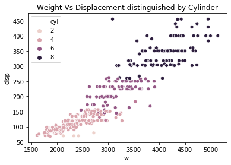

```python
#D. Visualize a scatterplot for ‘wt’ and ‘disp’. Datapoints should be distinguishable by ‘cyl’.

sns.scatterplot(x='wt',y='disp',data=Cardf, hue='cyl')
plt.title("Weight Vs Displacement distinguished by Cylinder")
plt.show()
```

# E. Share insights for Q2.d.

**Weight vs displacement**

Weight and displacement are positively correlated ; when the weight increase displacement also increase

**No.of cylinder vs Displacement**

It is observed that car with less cylinder have less displacement . Hence, No.of cylinder and displacement is positively correlated; if no.of cylinder increases displacement increase

**No.of cylinder Vs Weight**

No.of cyinder is also positively correlated with weight . If no.of cylinder increase , weight of the car also increase

**No.of cylinder Vs Weight Vs Displacement**

No.of cylinder increases weight which in turn increase displacement

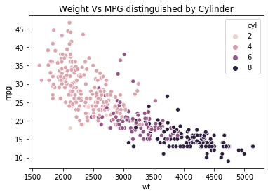

```python
#F. Visualize a scatterplot for ‘wt’ and ’mpg’. Datapoints should be distinguishable by ‘cyl’.
sns.scatterplot(x='wt',y='mpg',data=Cardf, hue='cyl')
plt.title("Weight Vs MPG distinguished by Cylinder")
plt.show()
```

# G. Share insights for Q2.f

**Weight vs mpg**

Weight and mpg are negatively correlated ; when the weight increase mpg decreases

**No.of cylinder vs MPG**

**No.of cylinder Vs Weight**

No.of cyinder is also positively correlated with weight . If no.of cylinder increase , weight of the car also increase

**No.of cylinder Vs Weight Vs MPG**

If No.of cylinder increases, weight increases which in turn reduce the MPG.

```python
#H. Check for unexpected values in all the features and datapoints with such values.
unexpected_values = ["n/a", "na", "--", " ","?","-","@","#","n-a"]
unexpected=False
for feature in Cardf.columns:
    #check for unexpected values like special characters.
    if (not Cardf[Cardf[feature].isin(unexpected_values)].empty):
        print("Unexpected value found in",feature,"column in the indices ", Cardf[Cardf[feature].isin(unexpected_values)].index)
        #changing unexpected values to NaN
        Cardf[feature].replace(unexpected_values,np.nan, inplace=True)
         #impute
        Cardf[feature].fillna( round(Cardf[feature].mean()), inplace=True)
        print("Imputed unexpected value in column",feature,"with",round(Cardf[feature].mean()))
        unexpected = True


if(not unexpected):
     print("No unexpected values")
```

```
Unexpected value found in hp column in the indices  Int64Index([32, 126, 330, 336, 354, 374], dtype='int64')
Imputed unexpected value in column hp with 104
```

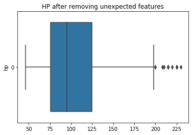

```python
ax = sns.boxplot(data = Cardf['hp'], orient = 'h')
plt.ylabel('hp')
plt.title("HP after removing unexpected features")
plt.show()
```

### 3. Clustering:

```python
#A. Apply K-Means clustering for 2 to 10 clusters.
from sklearn.cluster import KMeans
from scipy.spatial.distance import cdist
Cardfnumerical=Cardf.iloc[:,1:9]
Cardfscaled=Cardfnumerical.apply(zscore)
clusters=range(2,11)
meanDistortions=[]

for k in clusters:
    model=KMeans(n_clusters=k)
    model.fit(Cardfscaled)
    prediction=model.predict(Cardfscaled)
    meanDistortions.append(sum(np.min(cdist(Cardfscaled, model.cluster_centers_, 'euclidean'), axis=1)) / Cardfscaled.shape[0])
```

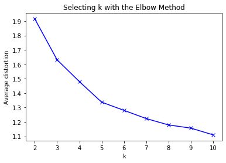

```python
#B. Plot a visual and find elbow point.
plt.plot(clusters, meanDistortions, 'bx-')
plt.xlabel('k')
plt.ylabel('Average distortion')
plt.title('Selecting k with the Elbow Method')
plt.show()
```

k=5 and k=3 are possible elbow point , will find optimal k value after calculating wss and silhoutee

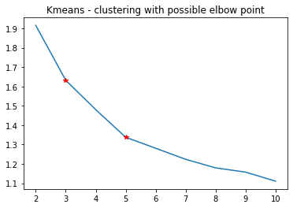

```python
#C. On the above visual, highlight which are the possible Elbow points.


plt.plot(clusters, meanDistortions)
plt.plot(clusters[1], meanDistortions[1],'r*') #k=3 at index 1 in cluster and dist array
plt.plot(clusters[3], meanDistortions[3],'r*')#k=5 at index 3 in cluster and dist array
plt.title("Kmeans - clustering with possible elbow point")
plt.show()
```

k=3 and K=5 are the possible elbow points , will find optimal k value after calculating WSS and Silhoutee

```python
#calculating WSS
wss=[]
for i in range(2,11):
    KM = KMeans(n_clusters=i)
    KM.fit(Cardfscaled)
    wss.append( KM.inertia_)
wss
```

```
[1589.5746138796112,
 1190.985392088508,
 988.8301053911673,
 831.1640600174571,
 752.3949248418461,
 698.3175170314744,
 639.1358064883674,
 596.4353037674405,
 569.7964154352553]
```

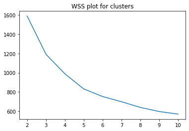

```python
plt.plot(range(2,11), wss)
plt.title("WSS plot for clusters")
plt.show()
```

**From WSS**

It is observed that cluster 2 to 3 is major drop in wss; better to stop at k=3

k=5 have decreased WSS than cluster =3

```python
#calculating Silhoutee
from sklearn.metrics import silhouette_score
silscore=[]
for i in range(2,11):
    KM = KMeans(n_clusters=i)
    KM.fit(Cardfscaled)
    labels=KM.labels_
    silscore.append(silhouette_score(Cardfscaled,labels))
silscore
```

```
[0.41463406147512627,
 0.3245407396966064,
 0.31214116521715213,
 0.3325130054260076,
 0.2878289947041519,
 0.29159793244734783,
 0.27927169644199246,
 0.27271128034534803,
 0.27065021174379755]
```

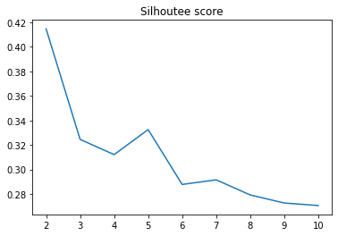

```python
plt.plot(range(2,11), silscore)
plt.title("Silhoutee score")
plt.show()
```

```python
#D. Train a K-means clustering model once again on the optimal number of clusters.
k_means = KMeans(n_clusters = 3,random_state=7)
k_means.fit(Cardfscaled)
labels = k_means.labels_
```

```python
#E. Add a new feature in the DataFrame which will have labels based upon cluster value.
Cardfscaled['Prediction']=labels
Cardf['Prediction']=labels
Cardfscaled.head()
```

|  | acc | cyl | disp | hp | mpg | origin | wt | yr | Prediction |
| --- | --- | --- | --- | --- | --- | --- | --- | --- | --- |
| 0 | -1.295498 | 1.498191 | 1.090604 | 0.669381 | -0.706439 | -0.715145 | 0.630870 | -1.627426 | 0 |
| 1 | -1.477038 | 1.498191 | 1.503514 | 1.586783 | -1.090751 | -0.715145 | 0.854333 | -1.627426 | 0 |
| 2 | -1.658577 | 1.498191 | 1.196232 | 1.193611 | -0.706439 | -0.715145 | 0.550470 | -1.627426 | 0 |
| 3 | -1.295498 | 1.498191 | 1.061796 | 1.193611 | -0.962647 | -0.715145 | 0.546923 | -1.627426 | 0 |
| 4 | -1.840117 | 1.498191 | 1.042591 | 0.931496 | -0.834543 | -0.715145 | 0.565841 | -1.627426 | 0 |

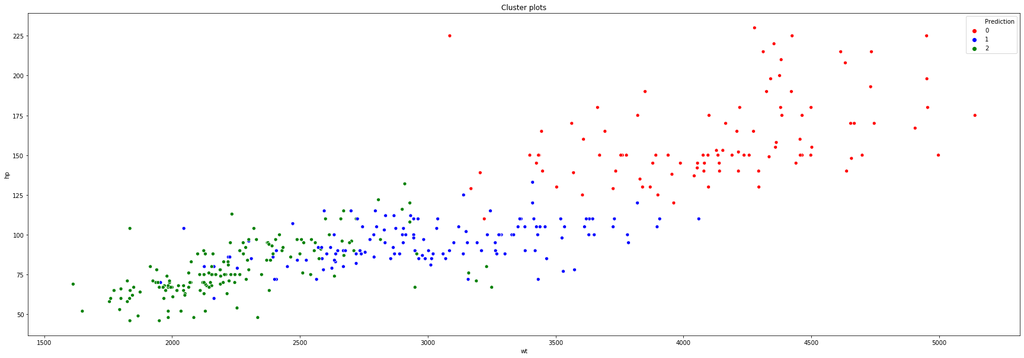

```python
#F. Plot a visual and color the datapoints based upon clusters
plt.figure(figsize=(30,10))
sns.scatterplot(data=Cardf, x='wt',y='hp',hue='Prediction', palette=['red','blue','green'])
plt.title("Cluster plots")
plt.show()
```

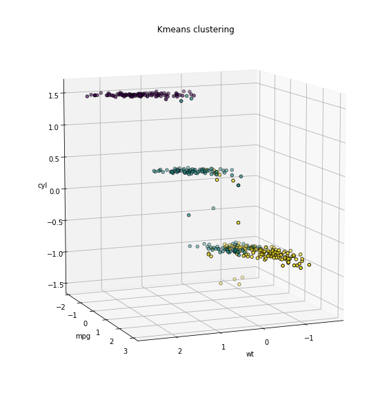

```python
from mpl_toolkits.mplot3d import Axes3D
fig=plt.figure(figsize=(8,8))
ax=Axes3D(fig,rect=[0,0,0.96,1],elev=10,azim=68)
ax.scatter(Cardfscaled['wt'],Cardfscaled['mpg'],Cardfscaled['cyl'],c=Cardfscaled['Prediction'],edgecolor='k')
ax.set_xlabel('wt')
ax.set_ylabel('mpg')
ax.set_zlabel('cyl')
ax.set_title('Kmeans clustering')
plt.show()
```

```python
#Cardf.iloc[:,1:9].head(1)
```

```python
#G. Pass a new DataPoint and predict which cluster it belongs to
k_means.predict([[16.0,6,305.0,170.0,22.0,4780,1,70]])
```

```
array([2])
```

# PART-B

DOMAIN: Automobile

• CONTEXT: The purpose is to classify a given silhouette as one of three types of vehicle, using a set of features extracted from the silhouette. The vehicle may be viewed from one of many different angles.

• DATA DESCRIPTION: The data contains features extracted from the silhouette of vehicles in different angles. Four "Corgie" model vehicles were used for the experiment: a double decker bus, Cheverolet van, Saab 9000 and an Opel Manta 400 cars. This particular combination of vehicles was chosen with the expectation that the bus, van and either one of the cars would be readily distinguishable, but it would be more difficult to distinguish between the cars. • All the features are numeric i.e. geometric features extracted from the silhouette.

• PROJECT OBJECTIVE: Apply dimensionality reduction technique – PCA and train a model and compare relative results

### 1. Data Understanding & Cleaning:

```python
#A. Read ‘vehicle.csv’ and save as DataFrame.
vehicle = pd.read_csv('vehicle.csv')
print("Shape",vehicle.shape)
vehicle.head()
```

```
Shape (846, 19)
```

|  | compactness | circularity | distance_circularity | radius_ratio | pr.axis_aspect_ratio | max.length_aspect_ratio | scatter_ratio | elongatedness | pr.axis_rectangularity | max.length_rectangularity | scaled_variance | scaled_variance.1 | scaled_radius_of_gyration | scaled_radius_of_gyration.1 | skewness_about | skewness_about.1 | skewness_about.2 | hollows_ratio | class |
| --- | --- | --- | --- | --- | --- | --- | --- | --- | --- | --- | --- | --- | --- | --- | --- | --- | --- | --- | --- |
| 0 | 95 | 48.0 | 83.0 | 178.0 | 72.0 | 10 | 162.0 | 42.0 | 20.0 | 159 | 176.0 | 379.0 | 184.0 | 70.0 | 6.0 | 16.0 | 187.0 | 197 | van |
| 1 | 91 | 41.0 | 84.0 | 141.0 | 57.0 | 9 | 149.0 | 45.0 | 19.0 | 143 | 170.0 | 330.0 | 158.0 | 72.0 | 9.0 | 14.0 | 189.0 | 199 | van |
| 2 | 104 | 50.0 | 106.0 | 209.0 | 66.0 | 10 | 207.0 | 32.0 | 23.0 | 158 | 223.0 | 635.0 | 220.0 | 73.0 | 14.0 | 9.0 | 188.0 | 196 | car |
| 3 | 93 | 41.0 | 82.0 | 159.0 | 63.0 | 9 | 144.0 | 46.0 | 19.0 | 143 | 160.0 | 309.0 | 127.0 | 63.0 | 6.0 | 10.0 | 199.0 | 207 | van |
| 4 | 85 | 44.0 | 70.0 | 205.0 | 103.0 | 52 | 149.0 | 45.0 | 19.0 | 144 | 241.0 | 325.0 | 188.0 | 127.0 | 9.0 | 11.0 | 180.0 | 183 | bus |

```python
vehicle.dtypes
```

```
compactness                      int64
circularity                    float64
distance_circularity           float64
radius_ratio                   float64
pr.axis_aspect_ratio           float64
max.length_aspect_ratio          int64
scatter_ratio                  float64
elongatedness                  float64
pr.axis_rectangularity         float64
max.length_rectangularity        int64
scaled_variance                float64
scaled_variance.1              float64
scaled_radius_of_gyration      float64
scaled_radius_of_gyration.1    float64
skewness_about                 float64
skewness_about.1               float64
skewness_about.2               float64
hollows_ratio                    int64
class                           object
dtype: object
```

```python
#encoding categorical columns
le=LabelEncoder()
vehicle['class'] = le.fit_transform(vehicle['class'])
vehicle['class'].value_counts()
```

```
1    429
0    218
2    199
Name: class, dtype: int64
```

```python
#B. Check percentage of missing values and impute with correct approach.
round((vehicle.isnull().sum()/len(vehicle))*100,2)
```

```
compactness                    0.00
circularity                    0.59
distance_circularity           0.47
radius_ratio                   0.71
pr.axis_aspect_ratio           0.24
max.length_aspect_ratio        0.00
scatter_ratio                  0.12
elongatedness                  0.12
pr.axis_rectangularity         0.35
max.length_rectangularity      0.00
scaled_variance                0.35
scaled_variance.1              0.24
scaled_radius_of_gyration      0.24
scaled_radius_of_gyration.1    0.47
skewness_about                 0.71
skewness_about.1               0.12
skewness_about.2               0.12
hollows_ratio                  0.00
class                          0.00
dtype: float64
```

```python
#check unexpected data

unexpected_values = ["n/a", "na", "--", " ","?","-","@","#","n-a"]
unexpected=False
for feature in vehicle.columns:
    #check for unexpected values like special characters.
    if (not vehicle[vehicle[feature].isin(unexpected_values)].empty):
        print("Unexpected value found in",feature,"column in the indices ", vehicle[vehicle[feature].isin(unexpected_values)].index)
        #changing unexpected values to NaN
        vehicle.replace(unexpected_values,np.nan, inplace=True) #if unexpected values found it will be converted as NAN and imputed with right value in below steps
        unexpected = True
if(not unexpected):
     print("No unexpected values")
```

```
No unexpected values
```

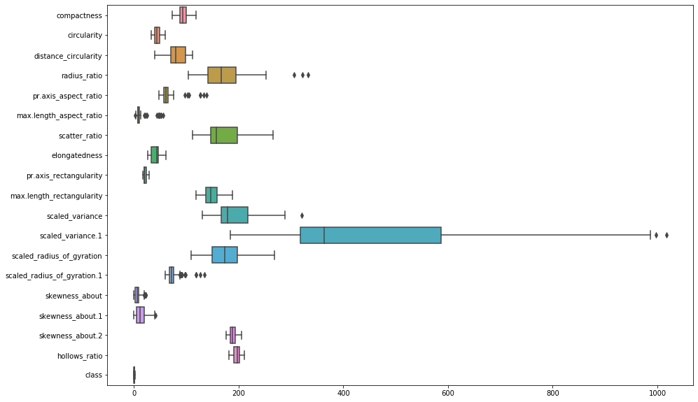

```python
#finding best approach for impute
fig = plt.figure(figsize = (15, 10))
ax = sns.boxplot(data = vehicle, orient = 'h')
```

There is negative skew feature[elongatedness] and positive skew feature [distnace circularity ,scatter ratio,scaled varianceand scaled variance.1] and rest are all normally distributed

So, imputing with mean will be a best suitable approach

```python
impute = SimpleImputer(missing_values = np.nan, strategy = 'mean', verbose = 1)
columns = list(vehicle.columns)
vehicle =pd.DataFrame(impute.fit_transform(vehicle),columns=columns)
```

```python
print("****missing value and unexpected values are handled***********")
round((vehicle.isnull().sum()/len(vehicle))*100,2)
```

```
****missing value and unexpected values are handled***********
```

```
compactness                    0.0
circularity                    0.0
distance_circularity           0.0
radius_ratio                   0.0
pr.axis_aspect_ratio           0.0
max.length_aspect_ratio        0.0
scatter_ratio                  0.0
elongatedness                  0.0
pr.axis_rectangularity         0.0
max.length_rectangularity      0.0
scaled_variance                0.0
scaled_variance.1              0.0
scaled_radius_of_gyration      0.0
scaled_radius_of_gyration.1    0.0
skewness_about                 0.0
skewness_about.1               0.0
skewness_about.2               0.0
hollows_ratio                  0.0
class                          0.0
dtype: float64
```

[figure not shown]

```python
# C. Visualize a Pie-chart and print percentage of values for variable ‘class’.
value=vehicle['class'].value_counts(sort=False)
plt.pie(value,labels=['bus','car','van'],autopct='%1.1f%%')
plt.title("Pie-chat for class variable")
plt.show()
```

```python
#D. Check for duplicate rows in the data and impute with correct approach.
if (vehicle.duplicated().sum()>0):
    vehicle.drop_duplicates(keep='first', inplace=True)
else :
    print("No Duplicates ")
```

```
No Duplicates
```

### 2. Data Preparation:

```python
#A. Split data into X and Y. [Train and Test optional]
X=vehicle.drop("class" , axis=1)
Y = vehicle['class']
X_train, X_test, Y_train, Y_test = train_test_split(X, Y, test_size=.20, random_state=7)
```

```python
#B. Standardize the Data.
from scipy.stats import zscore
X_train=X_train.apply(zscore)
X_test=X_test.apply(zscore)

Y_train = Y_train.values
Y_test = Y_test.values

display(X_train.shape, Y_train.shape, X_test.shape, Y_test.shape)
```

```
(676, 18)
```

```
(676,)
```

```
(170, 18)
```

```
(170,)
```

### 3. Model Building:

```python
#A. Train a base Classification model using SVM.
svmmodel = svm.SVC()
svmmodel.fit(X_train , Y_train)
Y_true, y_pred = Y_test, svmmodel.predict(X_test) # prediction with test data
Y_traintrue, y_trainpred = Y_train, svmmodel.predict(X_train) # prediction with train data
#Training and testing scores
print("Training score: ",svmmodel.score(X_train,Y_train))
print("Testing score: ",svmmodel.score(X_test,Y_test))
```

```
Training score:  0.9748520710059172
Testing score:  0.9705882352941176
```

```
CV results of train data 0.9585381913959612


classification report for train data
              precision    recall  f1-score   support

         0.0       0.98      0.98      0.98       176
         1.0       0.99      0.97      0.98       344
         2.0       0.93      0.97      0.95       156

    accuracy                           0.97       676
   macro avg       0.97      0.98      0.97       676
weighted avg       0.98      0.97      0.98       676


Confusion Matrix of train data:
 [[172   0   4]
 [  2 335   7]
 [  1   3 152]]
```

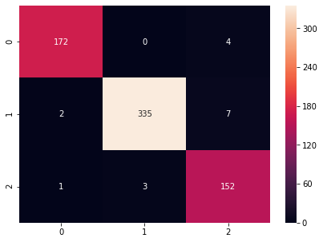

```
Accuracy Score:
 0.975
```

```python
#B. Print Classification metrics for train data.

num_folds = 10
kfold = StratifiedKFold(n_splits=num_folds, random_state=7,shuffle=True)
cv_results = cross_val_score(svmmodel, X_train, Y_train, cv=kfold, scoring='accuracy')
print("CV results of train data",cv_results.mean())


# Classification Report for train data
print('\n\nclassification report for train data\n{}'.format(classification_report(Y_traintrue, y_trainpred)))

# Confusion Matrix
cm = confusion_matrix(Y_traintrue, y_trainpred,labels=[0,1,2])
print('\nConfusion Matrix of train data:\n', cm)


df_cm = pd.DataFrame(cm, index = [i for i in [0,1,2]],columns = [i for i in [0,1,2]])
plt.figure(figsize = (7,5))
sns.heatmap(df_cm, annot=True ,fmt='g')
plt.show()


# Accuracy Score
auc = accuracy_score(Y_traintrue, y_trainpred)
print('\nAccuracy Score:\n', auc.round(3))
```

```python
covMatrix = np.cov(X_train,rowvar=False)
print(covMatrix)
```

```
[[ 1.00148148  0.68975584  0.79752317  0.69387048  0.08371018  0.12435776
   0.82206134 -0.79699442  0.82475006  0.68359803  0.77506842  0.82660533
   0.59307411 -0.25252901  0.21318124  0.13647695  0.29364099  0.34543779]
 [ 0.68975584  1.00148148  0.79334554  0.63113623  0.15316441  0.23780944
   0.84917154 -0.82321173  0.84664762  0.96382615  0.80396685  0.83991905
   0.92667719  0.04750298  0.13033558 -0.02339549 -0.10265648  0.0467393 ]
 [ 0.79752317  0.79334554  1.00148148  0.77556753  0.15645143  0.24711592
   0.90625279 -0.91544728  0.89407405  0.77515543  0.86643146  0.88913022
   0.7076728  -0.23722682  0.10403444  0.24532104  0.15387683  0.33471579]
 [ 0.69387048  0.63113623  0.77556753  1.00148148  0.65839479  0.43525047
   0.74311853 -0.79931679  0.71796399  0.58260185  0.78885125  0.72823486
   0.54365984 -0.20920938  0.02241624  0.17011407  0.38586061  0.47232539]
 [ 0.08371018  0.15316441  0.15645143  0.65839479  1.00148148  0.64713577
   0.10604676 -0.18653671  0.08279487  0.12752194  0.24895919  0.09188531
   0.1180886   0.11571541 -0.08993958 -0.02604496  0.24917754  0.27746906]
 [ 0.12435776  0.23780944  0.24711592  0.43525047  0.64713577  1.00148148
   0.1510859  -0.16443304  0.14894374  0.29161922  0.286045    0.13003667
   0.18080954  0.28285979 -0.01065559  0.03085185 -0.02972163  0.14191406]
 [ 0.82206134  0.84917154  0.90625279  0.74311853  0.10604676  0.1510859
   1.00148148 -0.97099074  0.99032966  0.81265428  0.95806232  0.99505179
   0.803153   -0.02734261  0.06037332  0.19801324  0.01129858  0.11467005]
 [-0.79699442 -0.82321173 -0.91544728 -0.79931679 -0.18653671 -0.16443304
  -0.97099074  1.00148148 -0.94921572 -0.77935176 -0.94529121 -0.95580013
  -0.7684001   0.10773805 -0.03210738 -0.17094205 -0.12431749 -0.21801358]
 [ 0.82475006  0.84664762  0.89407405  0.71796399  0.08279487  0.14894374
   0.99032966 -0.94921572  1.00148148  0.81665632  0.94579317  0.99087127
   0.80249673 -0.01153803  0.06913698  0.19790476 -0.01368661  0.09384568]
 [ 0.68359803  0.96382615  0.77515543  0.58260185  0.12752194  0.29161922
   0.81265428 -0.77935176  0.81665632  1.00148148  0.75640656  0.80168828
   0.87133188  0.03970126  0.12086339 -0.01918405 -0.10283345  0.07469979]
 [ 0.77506842  0.80396685  0.86643146  0.78885125  0.24895919  0.286045
   0.95806232 -0.94529121  0.94579317  0.75640656  1.00148148  0.95750539
   0.79041661  0.09538129  0.01906327  0.18365553  0.0152307   0.07552955]
 [ 0.82660533  0.83991905  0.88913022  0.72823486  0.09188531  0.13003667
   0.99505179 -0.95580013  0.99087127  0.80168828  0.95750539  1.00148148
   0.80102286 -0.01334442  0.06688378  0.18411474  0.01104651  0.09731783]
 [ 0.59307411  0.92667719  0.7076728   0.54365984  0.1180886   0.18080954
   0.803153   -0.7684001   0.80249673  0.87133188  0.79041661  0.80102286
   1.00148148  0.19235689  0.15570815 -0.06596581 -0.22321026 -0.11842521]
 [-0.25252901  0.04750298 -0.23722682 -0.20920938  0.11571541  0.28285979
  -0.02734261  0.10773805 -0.01153803  0.03970126  0.09538129 -0.01334442
   0.19235689  1.00148148 -0.10955172 -0.11635599 -0.76584444 -0.82370914]
 [ 0.21318124  0.13033558  0.10403444  0.02241624 -0.08993958 -0.01065559
   0.06037332 -0.03210738  0.06913698  0.12086339  0.01906327  0.06688378
   0.15570815 -0.10955172  1.00148148 -0.03792112  0.11466785  0.08881614]
 [ 0.13647695 -0.02339549  0.24532104  0.17011407 -0.02604496  0.03085185
   0.19801324 -0.17094205  0.19790476 -0.01918405  0.18365553  0.18411474
  -0.06596581 -0.11635599 -0.03792112  1.00148148  0.07671023  0.19058477]
 [ 0.29364099 -0.10265648  0.15387683  0.38586061  0.24917754 -0.02972163
   0.01129858 -0.12431749 -0.01368661 -0.10283345  0.0152307   0.01104651
  -0.22321026 -0.76584444  0.11466785  0.07671023  1.00148148  0.89079125]
 [ 0.34543779  0.0467393   0.33471579  0.47232539  0.27746906  0.14191406
   0.11467005 -0.21801358  0.09384568  0.07469979  0.07552955  0.09731783
  -0.11842521 -0.82370914  0.08881614  0.19058477  0.89079125  1.00148148]]
```

```python
#C. Apply PCA on the data with 10 components.
pca = PCA(n_components = 10, random_state = 7)
pca.fit(X_train)
X_train_reduced = pca.fit_transform(X_train)
X_test_reduced = pca.fit_transform(X_test)
display(X_train_reduced.shape, X_test_reduced.shape)
```

```
(676, 10)
```

```
(170, 10)
```

```python
print(pca.explained_variance_)
```

```
[9.43354294 2.9661561  2.03555257 1.17489487 0.91150639 0.5519683
 0.33590708 0.22998551 0.15397167 0.09917809]
```

```python
print(pca.components_)
```

```
[[ 2.70399431e-01  2.93089789e-01  3.04958688e-01  2.62585149e-01
   8.75783536e-02  1.32362370e-01  3.15172346e-01 -3.12555781e-01
   3.11520472e-01  2.80209321e-01  3.05188684e-01  3.11807119e-01
   2.68429314e-01 -9.81874019e-03  6.89402309e-02  8.20801210e-02
   2.50387711e-02  8.13857864e-02]
 [-1.64321037e-01  1.37130538e-01 -6.37718411e-02 -1.72747395e-01
  -6.74935550e-02  3.29186160e-02  4.41808104e-02  5.98262551e-03
   5.11029574e-02  1.18286234e-01  5.49927186e-02  4.28752024e-02
   2.15208492e-01  4.75106544e-01 -5.42439917e-02 -1.46733790e-01
  -5.46073912e-01 -5.44501669e-01]
 [-7.04977752e-02 -5.49675645e-02 -6.58276370e-02  2.96917016e-01
   6.33297637e-01  5.40727864e-01 -1.26045318e-01  8.36842269e-02
  -1.43924444e-01 -4.89755820e-02  1.12818845e-01 -1.37376184e-01
  -5.70239908e-02  3.23087124e-01  4.96354520e-02 -1.03123437e-01
   6.21642650e-02  6.21284434e-02]
 [ 1.27652842e-01  1.94419928e-01 -8.78952045e-02 -5.78684943e-02
  -2.39130302e-02 -6.97090490e-02 -8.25597445e-02  6.45373769e-02
  -8.14185449e-02  1.74434578e-01 -1.41426570e-01 -8.79874918e-02
   2.10241130e-01 -7.74178798e-02  6.27638995e-01 -6.26123291e-01
   1.27488434e-01  3.47854282e-02]
 [ 1.23955324e-01 -1.11558967e-01  3.02855800e-02 -1.06861427e-01
  -1.27459664e-01  1.70388714e-01 -1.66071868e-02  7.32213305e-02
   6.71929043e-03 -5.53417937e-02 -2.13792198e-02 -2.49690186e-02
  -1.03033048e-01  1.43094278e-01  6.99761517e-01  6.02870653e-01
  -1.39371947e-01 -3.33727494e-02]
 [ 7.49092757e-02 -2.97448115e-01 -1.23218215e-01  2.65806593e-01
   1.36533137e-01 -4.54285506e-01  1.50822112e-01 -1.84025865e-01
   1.36107651e-01 -5.08685407e-01  2.32409979e-01  1.83263350e-01
  -1.27803391e-01  1.91152367e-01  2.08705755e-01 -1.67132166e-01
   8.41068003e-02 -2.05240757e-01]
 [-4.71839454e-01  1.91464848e-01  3.78281870e-04  1.80955234e-01
   3.98033022e-01 -4.46058869e-01 -6.98939626e-02 -1.15512818e-02
  -8.87268250e-02  7.51905757e-02 -1.44534118e-01 -8.00353384e-02
   3.98382598e-01 -1.42131292e-01  1.19500678e-01  3.33231364e-01
  -1.06286796e-02 -1.94433081e-02]
 [ 5.43186239e-01  1.59990957e-01 -4.08146280e-01 -7.00700404e-02
   6.62573891e-02 -2.66056796e-01 -9.24249595e-02  1.99043770e-01
  -8.92691580e-02  1.40831697e-01 -3.61156820e-03 -2.01487574e-02
   1.96208887e-01  4.01429055e-01 -1.88551412e-01  2.22218207e-01
   2.60385967e-01  6.26350904e-02]
 [ 5.26576700e-01 -2.42160392e-02  1.21854829e-01  2.19181436e-01
   3.07117659e-01 -1.18762811e-01 -5.49829106e-02  1.27711071e-01
  -5.32144601e-04  9.87547366e-03 -2.99594634e-01 -8.24614473e-02
  -1.52072996e-01 -3.44224585e-01 -5.91520504e-02 -1.47149874e-02
  -5.10273299e-01 -1.70635936e-01]
 [ 1.83465417e-01 -8.79566898e-02  3.29633508e-01  3.59647489e-02
  -1.84635617e-01  1.30641805e-01 -1.69596196e-01  1.53505133e-01
  -2.23035709e-01 -4.78180928e-01  2.08872966e-01 -1.64901348e-01
   6.16883784e-01 -8.70661478e-02 -7.35621221e-02  3.89708420e-03
  -2.53979104e-03 -4.88530672e-02]]
```

```python
print(pca.explained_variance_ratio_)
```

```
[0.52100286 0.16381712 0.11242104 0.06488798 0.05034137 0.03048452
 0.01855173 0.01270181 0.00850366 0.00547748]
```

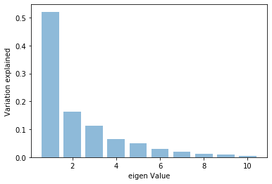

```python
plt.bar(list(range(1,11)),pca.explained_variance_ratio_,alpha=0.5, align='center')
plt.ylabel('Variation explained')
plt.xlabel('eigen Value')
plt.show()
```

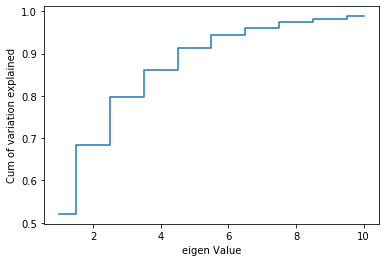

```python
#D. Visualize Cumulative Variance Explained with Number of Components.

plt.step(list(range(1,11)),np.cumsum(pca.explained_variance_ratio_), where='mid')
plt.ylabel('Cum of variation explained')
plt.xlabel('eigen Value')
plt.show()
```

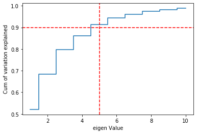

```python
#E. Draw a horizontal line on the above plot to highlight the threshold of 90%.
plt.step(list(range(1,11)),np.cumsum(pca.explained_variance_ratio_), where='mid')
plt.ylabel('Cum of variation explained')
plt.xlabel('eigen Value')
plt.axhline(y = 0.9, color = 'r', linestyle = '--')
plt.axvline(x = 5, color = 'r', linestyle = '--')
plt.show()
```

```python
#F. Apply PCA on the data. This time Select Minimum Components with 90% or above variance explained.
# Reducing the dimensions from 10 to 5
pca = PCA(n_components =5 , random_state = 7)
pca.fit(X_train)
X_train_reduced = pca.fit_transform(X_train)
X_test_reduced = pca.fit_transform(X_test)
display(X_train_reduced.shape, X_test_reduced.shape)
```

```
(676, 5)
```

```
(170, 5)
```

```python
#G. Train SVM model on components selected from above step.
svmmodel_pca = svm.SVC()
svmmodel_pca.fit(X_train_reduced , Y_train)
Y_true, y_pred = Y_test, svmmodel_pca.predict(X_test_reduced) #prediction with train data
Y_traintrue, ytrain_pred = Y_train, svmmodel_pca.predict(X_train_reduced) #prediction with test data
#Training and testing scores
print("Training score: ",svmmodel_pca.score(X_train_reduced,Y_train))
print("Testing score: ",svmmodel_pca.score(X_test_reduced,Y_true))
```

```
Training score:  0.7958579881656804
Testing score:  0.8117647058823529
```

```
CV results 0.7575504828797192


 classification report for train data
              precision    recall  f1-score   support

         0.0       0.83      0.69      0.75       176
         1.0       0.84      0.88      0.86       344
         2.0       0.67      0.72      0.70       156

    accuracy                           0.80       676
   macro avg       0.78      0.77      0.77       676
weighted avg       0.80      0.80      0.79       676


Confusion Matrix:
 [[121  31  24]
 [  9 304  31]
 [ 15  28 113]]
```

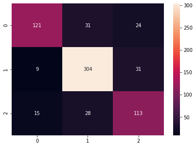

```
Accuracy Score:
 0.796
```

```python
#H. Print Classification metrics for train data of above model and share insights.
num_folds = 10
kfold = StratifiedKFold(n_splits=num_folds, random_state=7,shuffle=True)
cv_results = cross_val_score(svmmodel, X_train_reduced, Y_train, cv=kfold, scoring='accuracy')
print("CV results",cv_results.mean())


# Classification Report
print('\n\n classification report for train data\n{}'.format(classification_report(Y_traintrue,ytrain_pred)))

# Confusion Matrix
cm = confusion_matrix(Y_traintrue, ytrain_pred,labels=[0,1,2])
print('\nConfusion Matrix:\n', cm)


df_cm = pd.DataFrame(cm, index = [i for i in [0,1,2]],columns = [i for i in [0,1,2]])
plt.figure(figsize = (7,5))
sns.heatmap(df_cm, annot=True ,fmt='g')
plt.show()


# Accuracy Score
auc = accuracy_score(Y_traintrue, ytrain_pred)
print('\nAccuracy Score:\n', auc.round(3))
```

**---------------Insights-----------------------**

[output not shown]

**Complexity of the model is reduced from 18 to 5 dimensions with 16%-18% compromise in accuracy**

### 4. Performance Improvement

```python
#A. Train another SVM on the components out of PCA. Tune the parameters to improve performance.
# SVC with hyperparameter tuning -- Principal Components
svc = svm.SVC(random_state = 7)

params = {'C': [0.01, 0.05, 0.5, 1], 'kernel': ['linear', 'rbf']}

skf = StratifiedKFold(n_splits = 10, random_state = 7,shuffle=True)
grid_svc = GridSearchCV(svc, param_grid = params, n_jobs = -1, cv = skf)

grid_svc.fit(X_train_reduced, Y_train)

print('SVC Scores with Hyperparameter Tuning\n\n')
print('Best Hyper Parameters are: ', grid_svc.best_params_)
print('Best Score is: ', grid_svc.best_score_.round(3))
```

```
SVC Scores with Hyperparameter Tuning


Best Hyper Parameters are:  {'C': 1, 'kernel': 'rbf'}
Best Score is:  0.758
```

```python
#B. Share best Parameters observed from above step.
print('Best Hyper Parameters are: ', grid_svc.best_params_)
print('Best Score is: ', grid_svc.best_score_.round(3))
```

```
Best Hyper Parameters are:  {'C': 1, 'kernel': 'rbf'}
Best Score is:  0.758
```

```
SVC accuracy for train set: 0.796
SVC accuracy for test set: 0.812
SVC cross validation training score:  0.758

Accuracy Score of train data:
 0.796

n Classifiction Report for train data
              precision    recall  f1-score   support

         0.0       0.83      0.69      0.75       176
         1.0       0.84      0.88      0.86       344
         2.0       0.67      0.72      0.70       156

    accuracy                           0.80       676
   macro avg       0.78      0.77      0.77       676
weighted avg       0.80      0.80      0.79       676


Confusion Matrix of train data prediction:
 [[121  31  24]
 [  9 304  31]
 [ 15  28 113]]
```

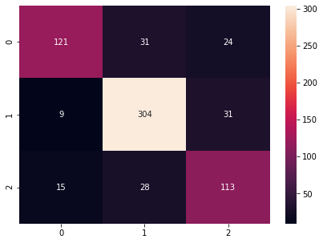

```python
#C. Print Classification metrics for train data of above model and share relative improvement in performance in all the models along with insights.
print('SVC accuracy for train set: {0:.3f}'.format(grid_svc.score(X_train_reduced, Y_train)))
print('SVC accuracy for test set: {0:.3f}'.format(grid_svc.score(X_test_reduced, Y_test)))

#prediction for train data
y_traintrue, y_trainpred = Y_train, grid_svc.predict(X_train_reduced)

# Cross Validation Score
grid_svc_score = cross_val_score(grid_svc, X_train_reduced, Y_train, cv = skf, scoring = 'accuracy')
print('SVC cross validation training score: ', round(grid_svc_score.mean(), 3).astype(str))

# Accuracy Score
auc = accuracy_score(y_traintrue, y_trainpred)
print('\nAccuracy Score of train data:\n', auc.round(3))

# Classification Report
print('\nn Classifiction Report for train data\n{}'.format(classification_report(y_traintrue, y_trainpred)))

# Confusion Matrix
cm = confusion_matrix(y_traintrue, y_trainpred,labels=[0,1,2])
print('\nConfusion Matrix of train data prediction:\n', cm)


df_cm = pd.DataFrame(cm, index = [i for i in [0,1,2]],columns = [i for i in [0,1,2]])
plt.figure(figsize = (7,5))
sns.heatmap(df_cm, annot=True ,fmt='g')
plt.show()
```

**---------------Insights-----------------------**

[output not shown]

**Final model**

principal components=5 [ complexity reduced ] Best parameters {'C': 1, 'kernel': 'rbf'} best score with less complexity = 75%

Initial base model performs well with 97% accuracy but the complexity of the model is high wth 18 dimension;

With Principal component analysis, the complexity of the model is reduced very much with only 5 dimensions. However the accuracy of the model seems to be 79% . Hence, we can simplify the model with less dimensions by compromising the accuracy

### 5. Data Understanding & Cleaning:

# A. Explain pre-requisite/assumptions of PCA.

1. Feature must be correlated to each other
2. Data should be normalized
3. Principal component with high variance have given importance and PC with lower variance are considered as noise.
4. increased outliers will degrade the performance

# B. Explain advantages and limitations of PCA.

Advantages of PCA:

1. It reduces the dimensions of the data thereby reduce the complexity of the model
2. Improve the performance with decreased computational time
3. Also helps in preventing the model from overfitting
4. Lesser dimension makes visualization easier.
5. Removes multi-collinearity to improve ML model performance

Disadvantages of PCA-

1. Information loss.
2. Data normalization must be needed before applying PCA
3. Independent variables are becoming less interpretable